# Tugas-Pertemuan-4

# White Noise

## Membangkitkan white noise dengan sebaran normal

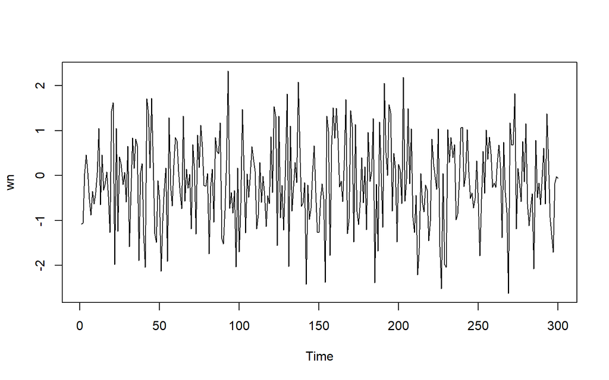

```r
set.seed(1049)
wn <- rnorm(300)
ts.plot(wn)
```

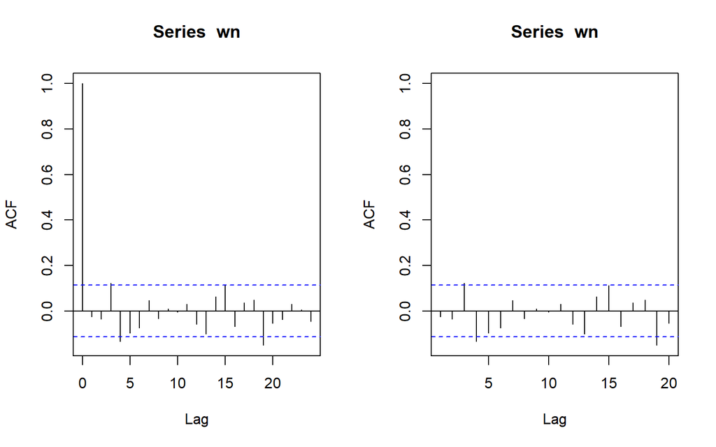

```r
par(mfrow = c(1, 2))
acf(wn)
acf(wn, xlim = c(1, 20))
```

# Pemodelan MA(2)

## Bangkitkan data Manual

```r
set.seed(1049)
ma <- c(1:300)
ma[1:2] <- wn[1:2]
```

```r
for(i in 3:300){
   ma[i] <- wn[i] + 0.4 * wn[i - 1] + 0.6 * wn[i - 2]
}
ma
```

```
##   [1] -1.0833667413 -1.0547735430 -1.0223917765 -0.1564747111  0.2750564550
##   [6] -0.2284391427 -1.0503441705 -1.0181425002 -1.2979207289 -0.8416057197
##  [11] -0.4701510921  0.8493520963 -0.1953445196  0.8313065344 -0.5323120518
##  [16] -0.0371959220 -0.1893597401 -0.5399041955 -1.3990292614  0.6557646700
##  [21]  1.4408619163 -0.4691905181  1.2308709771 -2.0054303566  0.5508262453
##  [26] -0.3205823450  0.1548096876  0.1479111344 -0.6741612890  0.4643576981
##  [31] -1.6683365593 -0.5939250766 -0.2546129724  0.2781019749  1.3773100414
##  [36]  1.0773018709 -1.1356286570 -0.2954382250 -0.8364722846 -1.1780037713
##  [41] -2.4080717721  0.0976733222  0.8415178788  1.7498269546  2.6145550709
##  [46]  1.0812244561 -0.1469393433 -1.8250830758 -1.4861481878 -1.4657713597
##  [51] -2.4103416415 -2.1772801321 -1.9732029247 -0.5512194991 -2.0144467539
##  [56]  0.6293668634 -0.8478443362  0.0130650373 -0.1696122990  0.5318681758
##  [61]  1.2461559758  0.9039201665  0.1053838516 -0.8414055742  0.7879755969
##  [66] -0.4887330227  0.7075980499 -0.5642798728  0.0001206627 -1.3463784643
##  [71]  0.2292103750 -0.3076048225 -0.8382746515  0.4545313847 -0.2455319812
```

[output cut: 45 more lines]

## Bangkitkan data dengan fungsi `arima.sim()`

```r
ma2 <- arima.sim(list(order=c(0,0,2), ma=c(0.4, 0.6)), n=300)
ma2
```

```
## Time Series:
## Start = 1
## End = 300
## Frequency = 1
##   [1] -1.0223917765 -0.1564747111  0.2750564550 -0.2284391427 -1.0503441705
##   [6] -1.0181425002 -1.2979207289 -0.8416057197 -0.4701510921  0.8493520963
##  [11] -0.1953445196  0.8313065344 -0.5323120518 -0.0371959220 -0.1893597401
##  [16] -0.5399041955 -1.3990292614  0.6557646700  1.4408619163 -0.4691905181
##  [21]  1.2308709771 -2.0054303566  0.5508262453 -0.3205823450  0.1548096876
##  [26]  0.1479111344 -0.6741612890  0.4643576981 -1.6683365593 -0.5939250766
##  [31] -0.2546129724  0.2781019749  1.3773100414  1.0773018709 -1.1356286570
##  [36] -0.2954382250 -0.8364722846 -1.1780037713 -2.4080717721  0.0976733222
##  [41]  0.8415178788  1.7498269546  2.6145550709  1.0812244561 -0.1469393433
##  [46] -1.8250830758 -1.4861481878 -1.4657713597 -2.4103416415 -2.1772801321
##  [51] -1.9732029247 -0.5512194991 -2.0144467539  0.6293668634 -0.8478443362
```

[output cut: 49 more lines]

## Plot Time Series

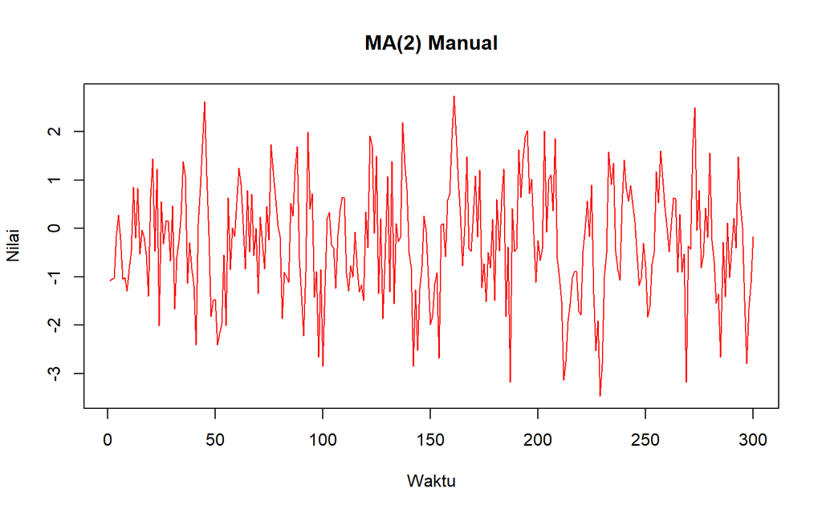

```r
ts.plot(ma, col = "red", main = "MA(2) Manual",
        ylab = "Nilai", xlab = "Waktu")
```

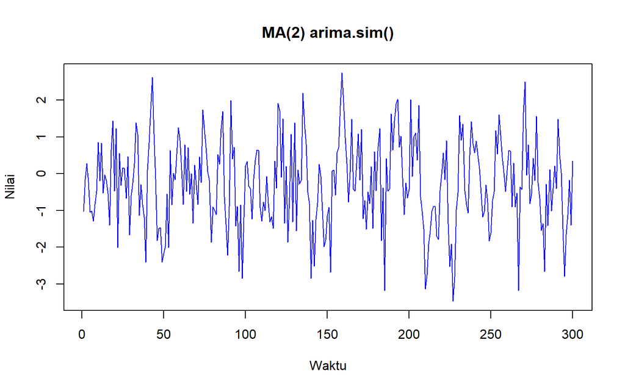

```r
ts.plot(ma2, col = "blue", main = "MA(2) arima.sim()",
        ylab = "Nilai", xlab = "Waktu")
```

Terlihat pada plot, bahwa kedua data memiliki pola yang mirip. Keduanya terlihat stasioner dalam rataan dan dalam ragam.

## Plot ACF

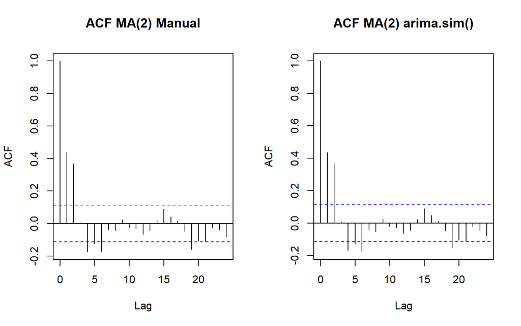

```r
par(mfrow = c(1, 2))
acf(ma, main = "ACF MA(2) Manual")
acf(ma2, main = "ACF MA(2) arima.sim()")
```

Plot ACF dari proses MA(2) baik yang dibangkitkan secara manual maupun menggunakan fungsi `arima.sim()` menunjukkan pola yang konsisten dengan teori. Pada kedua grafik, batang autokorelasi terlihat signifikan hingga lag ke-2, kemudian menurun drastis dan mendekati nol pada lag yang lebih tinggi. Pola ini mencerminkan sifat dasar proses MA(2), yaitu ACF akan berhenti (cut-off) setelah lag q, dalam hal ini q = 2. Hasil ini juga menegaskan bahwa data yang dihasilkan sudah sesuai dengan model yang dirancang. Perbedaan kecil antara grafik manual dan arima.sim(), misalnya ada batang pada lag yang lebih tinggi yang sedikit melewati batas, lebih disebabkan oleh variasi acak akibat ukuran sampel yang terbatas (n = 300), bukan karena kesalahan model. Secara keseluruhan, ACF yang ditampilkan menegaskan bahwa proses yang dibangkitkan benar-benar mengikuti sifat stasioner dari MA(2).

## Plot PACF

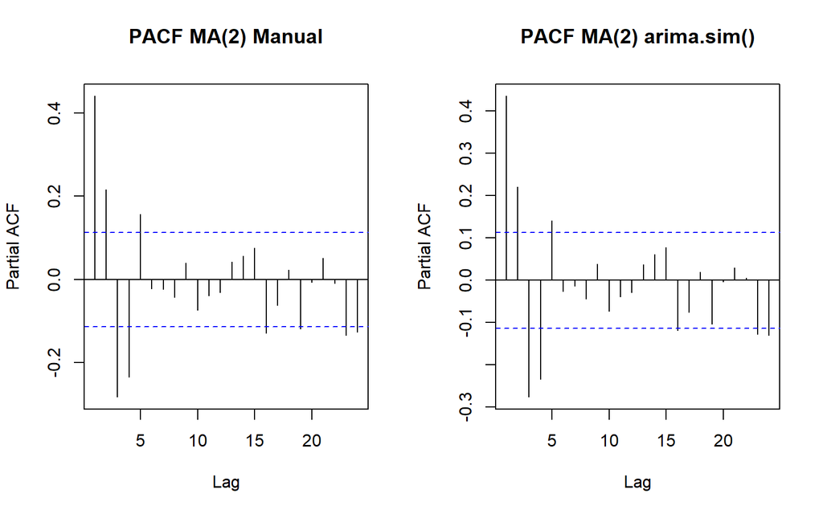

```r
par(mfrow = c(1, 2))
pacf(ma, main = "PACF MA(2) Manual")
pacf(ma2, main = "PACF MA(2) arima.sim()")
```

Plot PACF dari proses MA(2) baik hasil bangkitan manual maupun dengan fungsi `arima.sim()` memperlihatkan pola khas yang sesuai dengan teori. Pada grafik terlihat bahwa tidak ada cut-off yang jelas pada lag tertentu, melainkan batang PACF menunjukkan pola yang perlahan memudar (tailing off). Hal ini memang karakteristik dari proses MA, di mana ACF berhenti pada lag q sedangkan PACF justru menurun secara bertahap dan tidak langsung nol. Perbedaan kecil antara hasil manual dan `arima.sim()` misalnya perbedaan tinggi batang pada lag 3 atau fluktuasi pada lag-lag lebih besar—lebih disebabkan oleh variasi acak dari data simulasi dengan panjang sampel yang terbatas. Secara keseluruhan, pola PACF ini mengonfirmasi sifat dasar MA(2) bahwa hubungan parsial antar lag tidak terputus langsung, tetapi memudar seiring bertambahnya lag.

## Plot EACF

```r
library(TSA)
```

```r
eacf(ma)
```

```
## AR/MA
##   0 1 2 3 4 5 6 7 8 9 10 11 12 13
## 0 x x o x x x o o o o o  o  o  o
## 1 x x o x o x x o o o o  o  o  o
## 2 x x o x o x o o o o o  o  o  o
## 3 x x o x x o o o o o o  o  o  o
## 4 x x o x o x o o o o o  o  o  o
## 5 o x o x o o x o o o o  o  o  o
## 6 x o x x o o o o o o o  o  o  o
## 7 x o o x o o o o o o o  o  o  o
```

```r
eacf(ma2)
```

```
## AR/MA
##   0 1 2 3 4 5 6 7 8 9 10 11 12 13
## 0 x x o x x x o o o o o  o  o  o
## 1 x x o x o x x o o o o  o  o  o
## 2 x x o x o x o o o o o  o  o  o
## 3 x x o x x o o o o o o  o  o  o
## 4 x x o x o x o o o o o  o  o  o
## 5 x x o x o o x o o o o  o  o  o
## 6 x o x x o o x o o o o  o  o  o
## 7 x x o x o x x o o o o  o  o  o
```

## Scatter plot antar lag

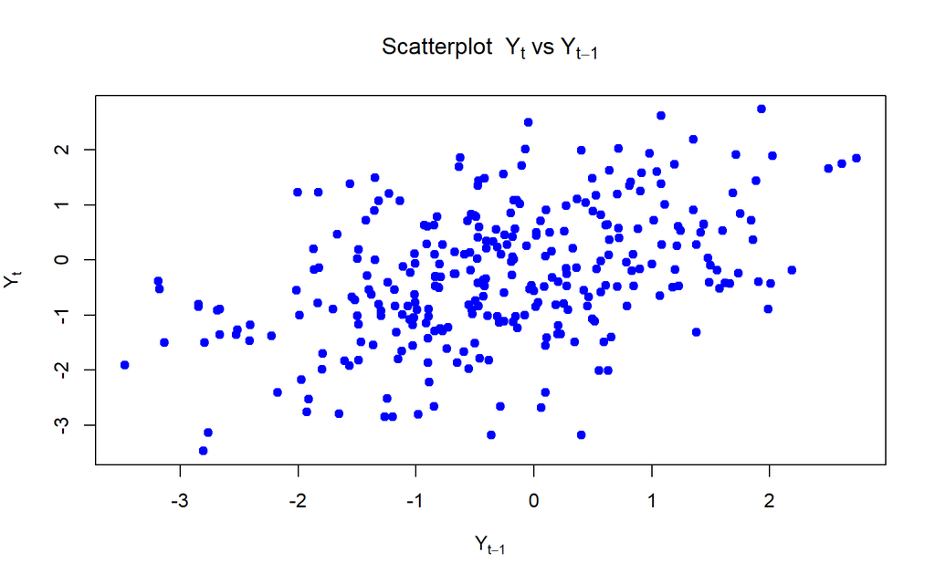

```r
# Scatterplot Yt vs Yt-1
plot(ma[-1], ma[-length(ma)],
     main = expression("Scatterplot " ~ Y[t] ~ "vs" ~ Y[t-1]),
     xlab = expression(Y[t-1]),
     ylab = expression(Y[t]),
     pch = 19, col = "blue")
```

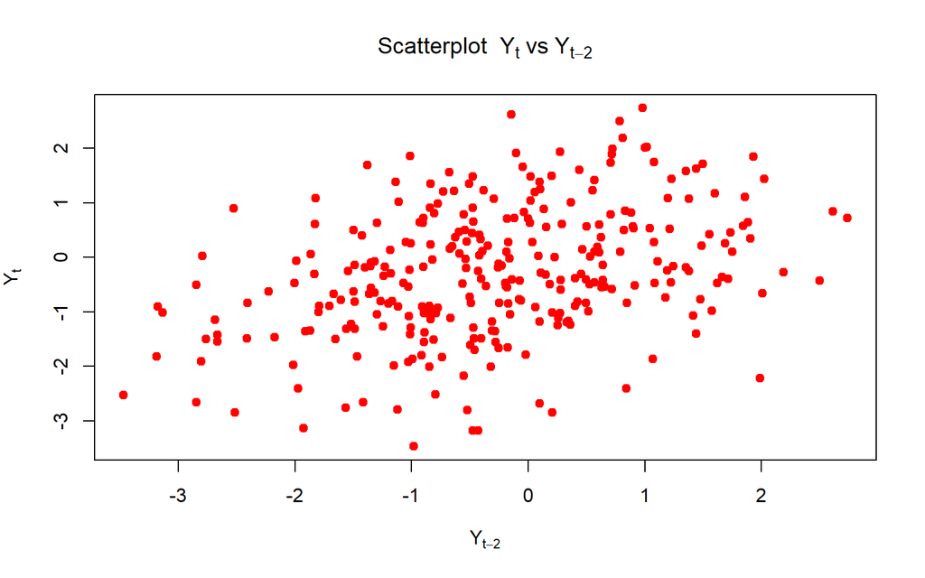

```r
# Scatterplot Yt vs Yt-2
plot(ma[-c(1,2)], ma[-((length(ma)-1):length(ma))],
     main = expression("Scatterplot " ~ Y[t] ~ "vs" ~ Y[t-2]),
     xlab = expression(Y[t-2]),
     ylab = expression(Y[t]),
     pch = 19, col = "red")
```

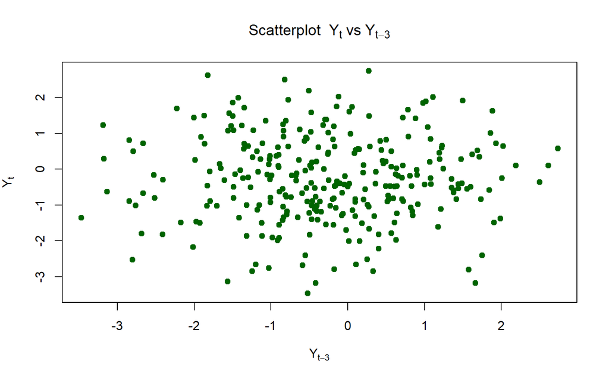

```r
# Scatterplot Yt vs Yt-3
plot(ma[-c(1,2,3)], ma[-((length(ma)-2):length(ma))],
     main = expression("Scatterplot " ~ Y[t] ~ "vs" ~ Y[t-3]),
     xlab = expression(Y[t-3]),
     ylab = expression(Y[t]),
     pch = 19, col = "darkgreen")
```

Scatter plot antara $Y_t$ dengan $Y_{t-1}$ dan $Y_{t-2}$ masih menunjukkan adanya pola tertentu, yang berarti data memiliki ketergantungan pada lag 1 dan lag 2. Namun, pada scatter plot dengan $Y_{t-3}$, pola sudah tidak terlihat lagi dan titik-titik tersebar acak. Hal ini menunjukkan bahwa hubungan antar variabel sudah hilang pada lag ke-3, sesuai dengan sifat proses MA(2) di mana ketergantungan hanya ada hingga dua lag sebelumnya.

## Perhitungan Autokorelasi

```r
# Panjang data
n <- length(ma)

# ---- Autokorelasi manual ----
acf1_hat <- cor(ma[2:n],     ma[1:(n-1)])   # Lag 1
acf2_hat <- cor(ma[3:n],     ma[1:(n-2)])   # Lag 2
acf3_hat <- cor(ma[4:n],     ma[1:(n-3)])   # Lag 3

# ---- Teoretis MA(2) ----
theta1 <- 0.4
theta2 <- 0.6
denom  <- 1 + theta1^2 + theta2^2

rho1_theory <- (theta1 + theta1*theta2) / denom
rho2_theory <- (theta2) / denom
rho3_theory <- 0

# ---- Rangkuman hasil ----
hasil <- data.frame(
  Lag = 1:3,
  Sample_Manual = c(acf1_hat, acf2_hat, acf3_hat),
  Teoretis      = c(rho1_theory, rho2_theory, rho3_theory)
)

print(round(hasil, 6))
```

```
##   Lag Sample_Manual Teoretis
## 1   1      0.440716 0.421053
## 2   2      0.368184 0.394737
## 3   3      0.004597 0.000000
```

Hasil empiris sangat konsisten dengan nilai teoretis. Proses yang dibangkitkan benar-benar menyerupai MA(2), di mana autokorelasi hanya signifikan pada lag 1 dan lag 2, lalu hilang pada lag > 2.

# Pemodelan AR(2)

Akan dibangkitkan data dengan model AR(2) sebanyak 300 data yang memiliki nilai $\phi_1 = 0.5$ dan $\phi_2 = 0.2$. Rumusan model tersebut adalah sebagai berikut:

$$Y_t = e_t+0.5Y_{t-1}+0.2Y_{t-2}$$

## Bangkitkan Manual

```r
set.seed(1049)
n <- 300
phi1 <- 0.5
phi2 <- 0.2

# White noise sudah ada dengan nama wn
ar2 <- numeric(n)
ar2[1:2] <- wn[1:2]  # inisialisasi

for(i in 3:n){
  ar2[i] <- phi1 * ar2[i-1] + phi2 * ar2[i-2] + wn[i]
}
ar2
```

```
##   [1] -1.083366741 -1.054773543 -0.694522434 -0.101641585 -0.127021172
##   [6] -0.611304293 -1.208036860 -1.077150363 -1.411566565 -1.299742826
##  [11] -0.872093623  0.356437961 -0.648572260  0.207797001 -0.351022709
##  [16] -0.317542497 -0.149775259 -0.599826212 -1.591845705  0.521525644
##  [21]  1.565476630 -1.093828497  0.815551061 -1.047645354  0.055153864
##  [26]  0.073112096 -0.149148983  0.013614843 -0.608568948  0.352874673
##  [31] -1.524059540 -1.046528384  0.006610199 -0.048728993  0.790547171
##  [36]  1.043030856 -1.207158799 -0.330199830 -0.136843122 -1.459204758
##  [41] -2.796958615  0.018194046  0.831810024  0.591420303  2.178613800
##  [46]  1.499072870 -0.108197898 -1.236873759 -0.757114637 -1.155334529
##  [51] -2.857447943 -2.668086434 -2.198402857 -1.461912860 -3.077724067
##  [56] -0.541586429 -1.105793395 -1.334161705 -0.656999521  0.247808703
##  [61]  0.762660095  0.520865213  0.020265718 -0.624004164  1.010970029
##  [66] -0.192630388  0.251451309 -0.191320553 -0.021184799 -1.237796983
##  [71]  0.067139983 -0.084340117 -1.333041689  0.215072795  0.018591190
```

[output cut: 45 more lines]

## Bangkitkan dengan fungsi `arima.sim()`

```r
ar2_sim <- arima.sim(list(order=c(2,0,0), ar=c(0.5, 0.2)), n=300, innov=wn)
ar2_sim
```

```
## Time Series:
## Start = 1
## End = 300
## Frequency = 1
##   [1] -1.265917258 -1.676858382 -1.042074957 -0.399834815 -0.345628291
##   [6] -0.780246499 -1.336229387 -1.175035068 -1.486147423 -1.356610195
##  [11] -0.915443479  0.323389559 -0.673766433  0.188590234 -0.365664927
##  [16] -0.328704959 -0.158284934 -0.606313541 -1.596791304  0.517755378
##  [21]  1.562602377 -1.096019677  0.813880621 -1.048918810  0.054183048
##  [26]  0.072371997 -0.149713196  0.013184716 -0.608896854  0.352624695
##  [31] -1.524250110 -1.046673665  0.006499445 -0.048813426  0.790482804
##  [36]  1.042981786 -1.207196208 -0.330228349 -0.136864863 -1.459221333
##  [41] -2.796971250  0.018184414  0.831802680  0.591414705  2.178609533
##  [46]  1.499069617 -0.108200379 -1.236875650 -0.757116079 -1.155335628
##  [51] -2.857448781 -2.668087073 -2.198403344 -1.461913231 -3.077724350
```

[output cut: 49 more lines]

## Plot Time Series

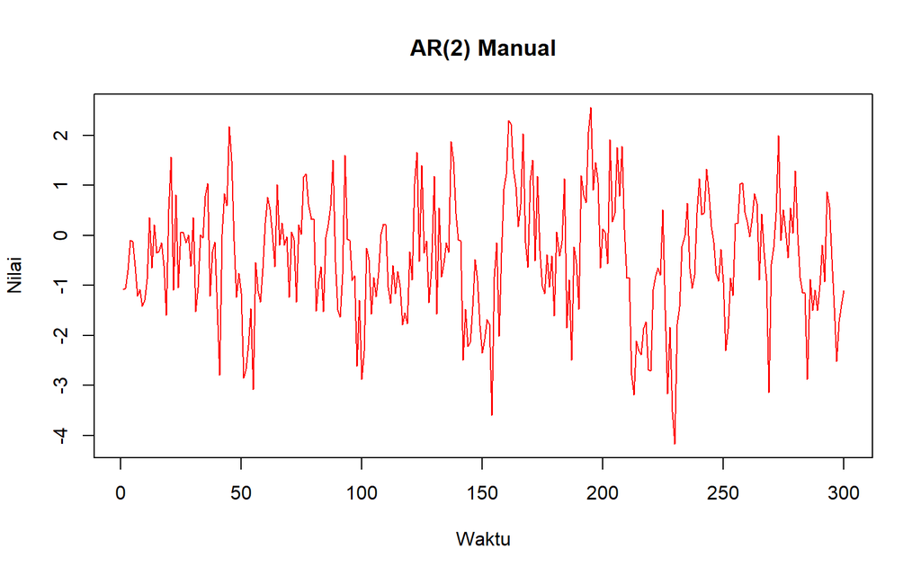

```r
ts.plot(ar2, col = "red", main = "AR(2) Manual",
        ylab = "Nilai", xlab = "Waktu")
```

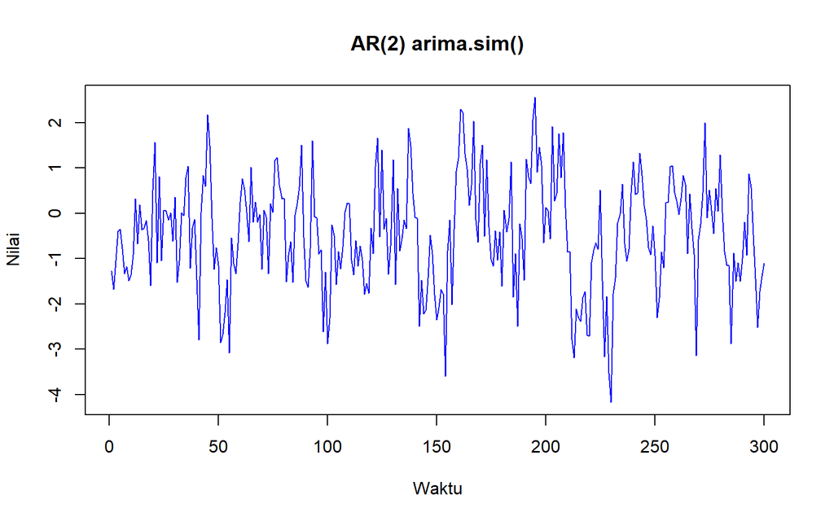

```r
ts.plot(ar2_sim, col = "blue", main = "AR(2) arima.sim()",
        ylab = "Nilai", xlab = "Waktu")
```

Terlihat pada plot deret waktu, bahwa kedua data memiliki pola yang mirip. Keduanya terlihat stasioner dalam rataan dan dalam ragam.

## Plot ACF

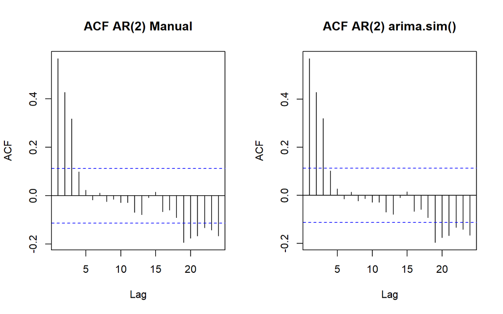

```r
par(mfrow = c(1, 2))
acf(ar2, main = "ACF AR(2) Manual")
acf(ar2_sim, main = "ACF AR(2) arima.sim()")
```

Plot ACF dari proses AR(2) baik hasil bangkitan manual maupun menggunakan fungsi `arima.sim()` memperlihatkan pola yang sesuai dengan teori. Pada kedua grafik terlihat bahwa autokorelasi tidak berhenti secara tiba-tiba, melainkan menurun secara bertahap (tailing off) seiring bertambahnya lag. Batang ACF masih cukup besar pada lag awal (lag 1 dan lag 2), kemudian mengecil perlahan namun tetap menunjukkan pola berosilasi hingga lag yang lebih tinggi.

## Plot PACF

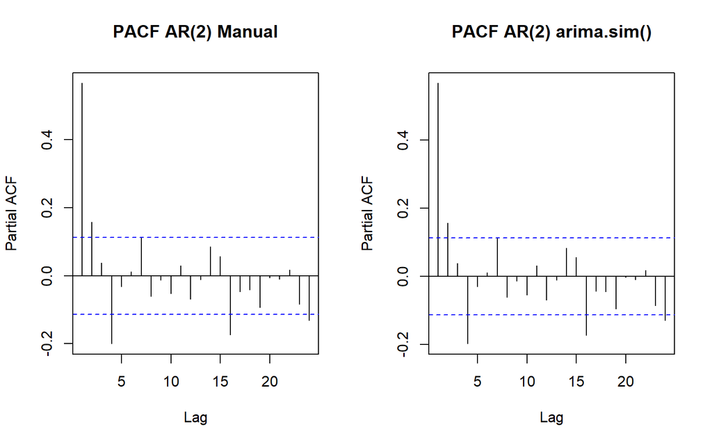

```r
par(mfrow = c(1, 2))
pacf(ar2, main = "PACF AR(2) Manual")
pacf(ar2_sim, main = "PACF AR(2) arima.sim()")
```

## Plot EACF

```r
library(TSA)
eacf(ar2)
```

```
## AR/MA
##   0 1 2 3 4 5 6 7 8 9 10 11 12 13
## 0 x x x o o o o o o o o  o  o  o
## 1 x o x o o o o o o o o  o  o  o
## 2 x o x o o o o o o o o  o  o  o
## 3 x x x o o o o o o o o  o  o  o
## 4 x o x o o o o o o o o  o  o  o
## 5 x o x x o o o o o o o  o  o  o
## 6 o x x x o o o o o o o  o  o  o
## 7 x x x x o x o o o o o  o  o  o
```

```r
eacf(ar2_sim)
```

```
## AR/MA
##   0 1 2 3 4 5 6 7 8 9 10 11 12 13
## 0 x x x o o o o o o o o  o  o  o
## 1 x o x o o o o o o o o  o  o  o
## 2 x o x o o o o o o o o  o  o  o
## 3 x x x o o o o o o o o  o  o  o
## 4 x o x o o o o o o o o  o  o  o
## 5 x o x x o o o o o o o  o  o  o
## 6 o x x x o o o o o o o  o  o  o
## 7 x x x x o x o o o o o  o  o  o
```

## Scatter plot antar lag

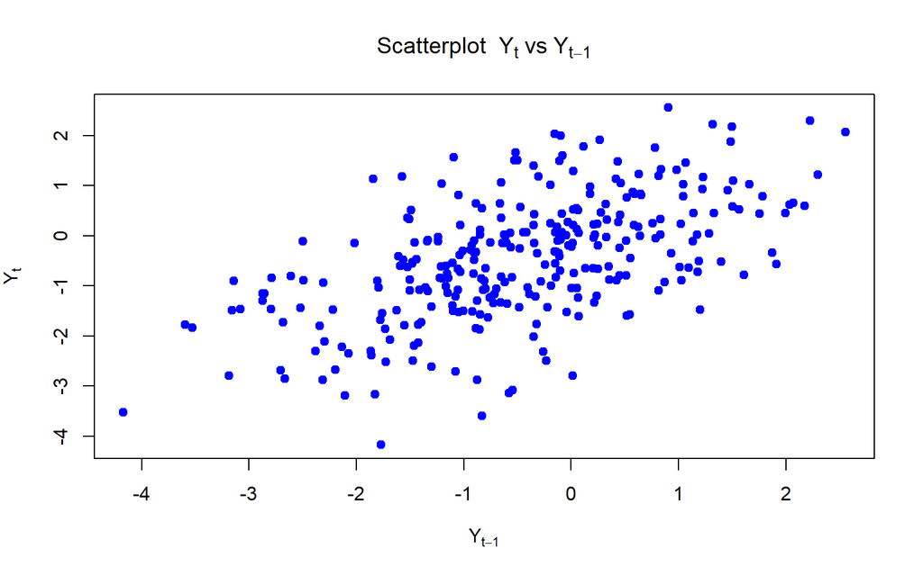

```r
# Scatterplot Yt vs Yt-1
plot(ar2[-1], ar2[-length(ar2)],
     main = expression("Scatterplot " ~ Y[t] ~ "vs" ~ Y[t-1]),
     xlab = expression(Y[t-1]), ylab = expression(Y[t]),
     pch = 19, col = "blue")
```

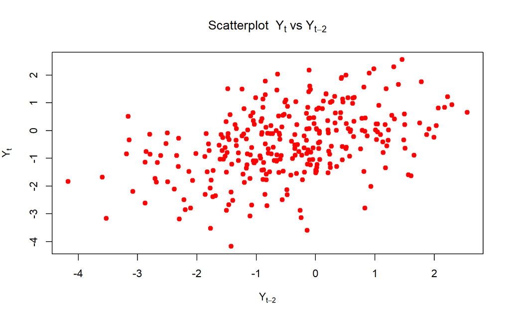

```r
# Scatterplot Yt vs Yt-2
plot(ar2[-c(1,2)], ar2[-((length(ar2)-1):length(ar2))],
     main = expression("Scatterplot " ~ Y[t] ~ "vs" ~ Y[t-2]),
     xlab = expression(Y[t-2]), ylab = expression(Y[t]),
     pch = 19, col = "red")
```

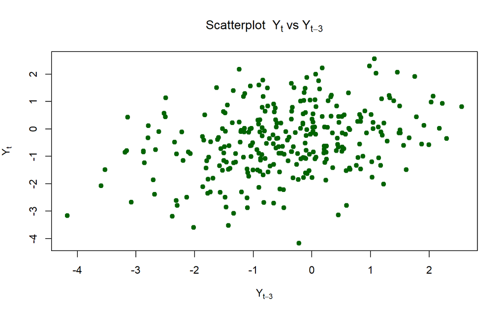

```r
# Scatterplot Yt vs Yt-3
plot(ar2[-c(1,2,3)], ar2[-((length(ar2)-2):length(ar2))],
     main = expression("Scatterplot " ~ Y[t] ~ "vs" ~ Y[t-3]),
     xlab = expression(Y[t-3]), ylab = expression(Y[t]),
     pch = 19, col = "darkgreen")
```

Scatter plot dari proses AR(2) memperlihatkan bahwa pada hubungan $Y_t$ dengan $Y_{t-1}$ dan $Y_{t-2}$ masih terdapat pola yang cukup jelas, artinya data memiliki ketergantungan kuat pada dua lag sebelumnya sesuai dengan definisi model. Namun, pada scatter plot $Y_t$ dengan $Y_{t-3}$, titik-titik sudah mulai menyebar lebih acak dan pola hubungan terlihat jauh lebih lemah. Hal ini menegaskan bahwa pengaruh lag signifikan hanya sampai lag ke-2, sementara pada lag ke-3 dan seterusnya ketergantungan mulai memudar. Pola ini konsisten dengan sifat dasar AR(2), di mana nilai sekarang dipengaruhi oleh dua periode sebelumnya dan efek lag lebih panjang akan berangsur hilang.

## Perhitungan Autokorelasi

```r
# Panjang data
n <- length(ar2)

# ---- Autokorelasi manual ----
acf1_hat <- cor(ar2[2:n], ar2[1:(n-1)])   # Lag 1
acf2_hat <- cor(ar2[3:n], ar2[1:(n-2)])   # Lag 2
acf3_hat <- cor(ar2[4:n], ar2[1:(n-3)])   # Lag 3

# ---- Teoretis AR(2) ----
phi1 <- 0.5
phi2 <- 0.2

rho1_theory <- phi1 / (1 - phi2)
rho2_theory <- phi1 * rho1_theory + phi2
rho3_theory <- phi1 * rho2_theory + phi2 * rho1_theory

# ---- Rangkuman hasil ----
hasil <- data.frame(
  Lag = 1:3,
  Sample_Manual = c(acf1_hat, acf2_hat, acf3_hat),
  Teoretis      = c(rho1_theory, rho2_theory, rho3_theory)
)

print(round(hasil, 6))
```

```
##   Lag Sample_Manual Teoretis
## 1   1      0.566674  0.62500
## 2   2      0.428550  0.51250
## 3   3      0.319756  0.38125
```

Hasil empiris sejalan dengan teori: proses AR(2) memperlihatkan autokorelasi yang tidak terhenti tiba-tiba, melainkan menurun secara bertahap (tailing off) seiring bertambahnya lag. Perbedaan kecil antara sampel dan teori disebabkan oleh variasi acak dari data simulasi, namun pola keseluruhan konsisten dengan sifat dasar AR(2)

# Pemodelan ARMA(2,2)

Akan dibangkitkan suatu data dengan model ARMA(2,2) sebanyak 300 data yang memiliki nilai parameter $\phi_1 = 0.5$ dan $\phi_2 = 0.2$ serta $\theta_1 = 0.4$ dan $\theta_2 = 0.6$. Model tersebut adalah sebagai berikut:

## Bangkitkan Manual

```r
set.seed(1049)
n <- 300
phi1 <- 0.5; phi2 <- 0.2
theta1 <- 0.4; theta2 <- 0.6

# White noise sudah ada: wn
arma22 <- numeric(n)
arma22[1:2] <- wn[1:2]  # inisialisasi

for(i in 3:n){
  arma22[i] <- phi1*arma22[i-1] + phi2*arma22[i-2] +
               wn[i] + theta1*wn[i-1] + theta2*wn[i-2]
}
arma22
```

```
##   [1] -1.083366741 -1.054773543 -1.766451896 -1.250655368 -0.703561608
##   [6] -0.830351020 -1.606232002 -1.987328705 -2.612831482 -2.545487202
##  [11] -2.265460989 -0.792475839 -1.044674637  0.150474048 -0.666009955
##  [16] -0.340106090 -0.492614776 -0.854232802 -1.924668617 -0.477416199
##  [21]  0.817220093 -0.156063711  1.316283140 -1.378501529  0.124832109
##  [26] -0.533866596 -0.087157189 -0.002440779 -0.692813116  0.117462984
##  [31] -1.748167691 -1.444516325 -1.326504673 -0.674053627  0.774982293
##  [36]  1.329982292 -0.315641052 -0.187262293 -0.993231641 -1.712072051
##  [41] -3.462754126 -1.976118151 -0.839092022  0.935057314  2.914265323
##  [46]  2.725368581  1.798598012 -0.380710354 -1.316783762 -2.200305312
##  [51] -3.773851050 -4.504266719 -4.980106494 -3.942126090 -4.981531098
##  [56] -2.649823904 -3.169062508 -2.101430997 -1.854140299 -0.815488173
##  [61]  0.467583829  0.974614447  0.686207841 -0.303378765  0.773527783
##  [66] -0.162644884  0.780981164 -0.206318267  0.053157762 -1.361063237
##  [71] -0.440689691 -0.800162315 -1.326493747 -0.368747952 -0.695204707
```

[output cut: 45 more lines]

## Bangkitkan dengan fungsi `arima.sim()`

```r
# Bangkitkan dengan arima.sim bawaan R
arma22_sim <- arima.sim(list(order=c(2,0,2),
                              ar=c(0.5,0.2),
                              ma=c(0.4,0.6)),
                         n=300)
```

## Plot Time Series

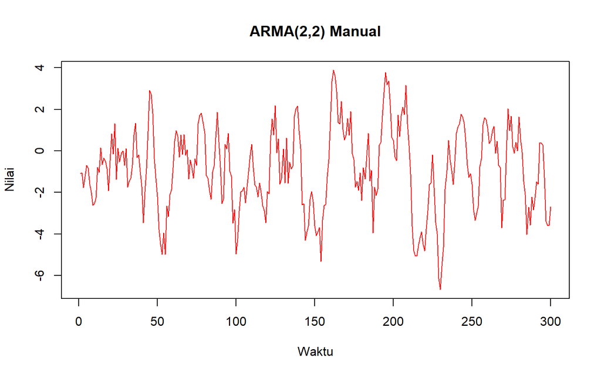

```r
ts.plot(arma22, col="red", main="ARMA(2,2) Manual",
        ylab="Nilai", xlab="Waktu")
```

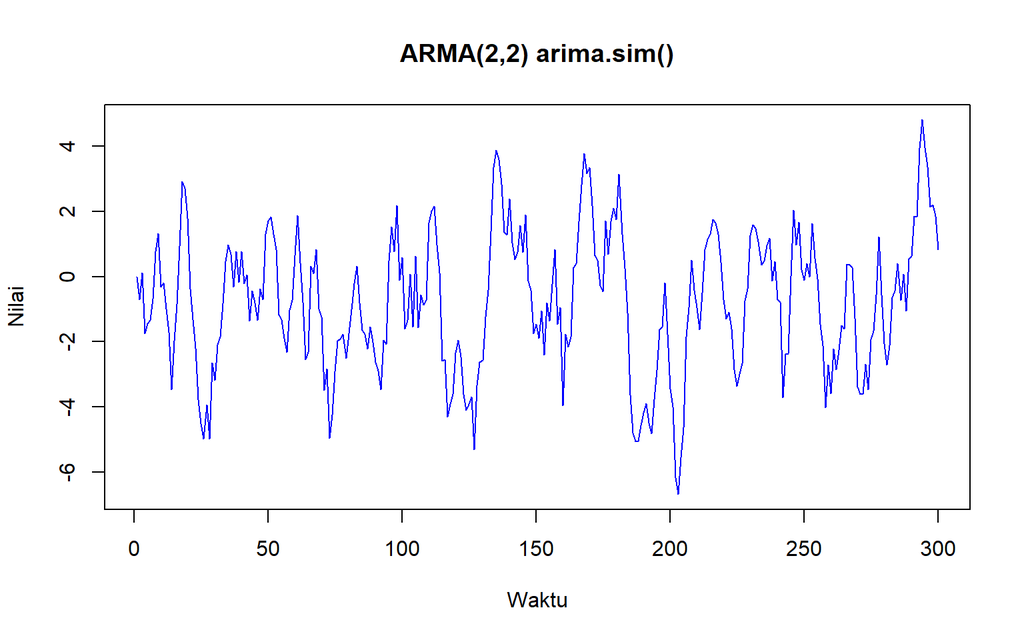

```r
ts.plot(arma22_sim, col="blue", main="ARMA(2,2) arima.sim()",
        ylab="Nilai", xlab="Waktu")
```

Kedua grafik, baik manual maupun `arima.sim()`, memperlihatkan pola yang hampir sama: adanya puncak-puncak (peaks) dan lembah (troughs) yang terjadi secara bergantian, menandakan bahwa model AR dan MA bekerja bersama dalam memengaruhi nilai $Y_t$. Hal ini konsisten dengan karakteristik proses ARMA, di mana bagian AR memberikan ketergantungan jangka panjang yang memudar, sementara bagian MA menambahkan ketergantungan jangka pendek yang lebih terbatas. Dengan demikian, hasil simulasi manual maupun `arima.sim()` sama-sama mencerminkan sifat teoretis dari proses ARMA(2,2) yang stasioner dengan fluktuasi acak terkontrol.

## Plot ACF

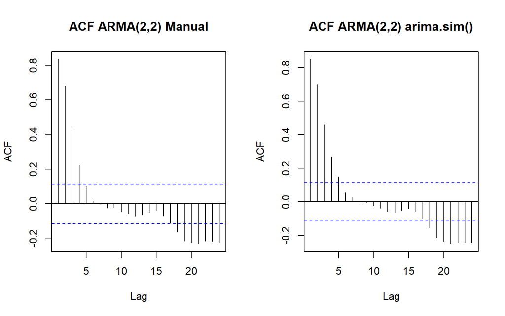

```r
par(mfrow=c(1,2))
acf(arma22, main="ACF ARMA(2,2) Manual")
acf(arma22_sim, main="ACF ARMA(2,2) arima.sim()")
```

Plot ACF dari proses ARMA(2,2) baik hasil bangkitan manual maupun dengan fungsi `arima.sim()` memperlihatkan pola yang sesuai dengan teori. Pada kedua grafik terlihat bahwa autokorelasi awal (lag 1 hingga lag 2) cukup besar, lalu menurun secara bertahap dan perlahan menuju nol. Tidak ada tanda cut-off yang jelas setelah lag ke-2, melainkan pola autokorelasi berosilasi dan semakin melemah seiring bertambahnya lag.

Pola seperti ini merupakan ciri khas dari proses ARMA, di mana ACF tidak berhenti tiba-tiba seperti pada MA murni, dan juga tidak memudar terlalu mulus seperti AR murni, melainkan kombinasi keduanya. Konsistensi antara grafik manual dan `arima.sim()` menunjukkan bahwa proses yang dibangkitkan sudah sesuai dengan karakteristik ARMA(2,2). Hal ini sekaligus menegaskan bahwa data yang dihasilkan adalah stasioner, dengan autokorelasi yang melemah secara bertahap pada lag yang lebih panjang.

## Plot PACF

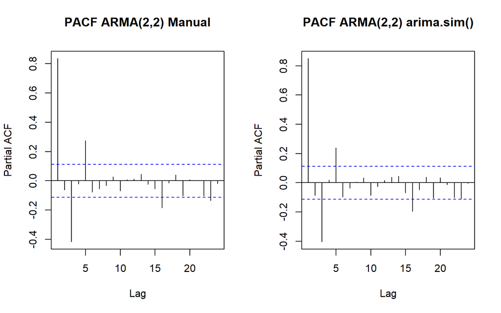

```r
par(mfrow=c(1,2))
pacf(arma22, main="PACF ARMA(2,2) Manual")
pacf(arma22_sim, main="PACF ARMA(2,2) arima.sim()")
```

Hal ini sesuai dengan sifat model ARMA, di mana PACF tidak terputus seperti pada model AR murni, melainkan menurun secara bertahap dengan kemungkinan osilasi. Konsistensi pola antara hasil manual dan `arima.sim()` memperkuat bahwa data yang dibangkitkan memang berasal dari proses ARMA(2,2). Dengan demikian, PACF ini membantu membedakan ARMA dari AR atau MA murni, karena ketergantungan parsialnya tidak berhenti pada lag tertentu tetapi perlahan memudar.

## Plot EACF

```r
eacf(arma22)
```

```
## AR/MA
##   0 1 2 3 4 5 6 7 8 9 10 11 12 13
## 0 x x x x o o o o o o o  o  o  o
## 1 o x x o o o o o o o o  o  o  o
## 2 x x o o o o o o o o o  o  o  o
## 3 o x o x o x o o o o o  o  o  o
## 4 o x x o o o o o o o o  o  o  o
## 5 x x x o o x o o o o o  o  o  o
## 6 x o x x x o o o o o o  o  o  o
## 7 x o o x x o o o o o o  o  o  o
```

```r
eacf(arma22_sim)
```

```
## AR/MA
##   0 1 2 3 4 5 6 7 8 9 10 11 12 13
## 0 x x x x x o o o o o o  o  o  o
## 1 o x x o o o o o o o o  o  o  o
## 2 x x o o o o o o o o o  o  o  o
## 3 o x o x o x o o o o o  o  o  o
## 4 o x x o o o o o o o o  o  o  o
## 5 x x x o o o o o o o o  o  o  o
## 6 x o x o x o o o o o o  o  o  o
## 7 o x o o o o o o o o o  o  o  o
```

EACF berhasil mengidentifikasi bahwa proses yang dibangkitkan memiliki komponen AR(2) dan MA(2). Pola segitiga nol (o) di sekitar titik (2,2) menegaskan bahwa model yang sesuai adalah ARMA(2,2), sehingga hasil simulasi manual dan `arima.sim()` sama-sama valid.

## Scatter plot antar lag

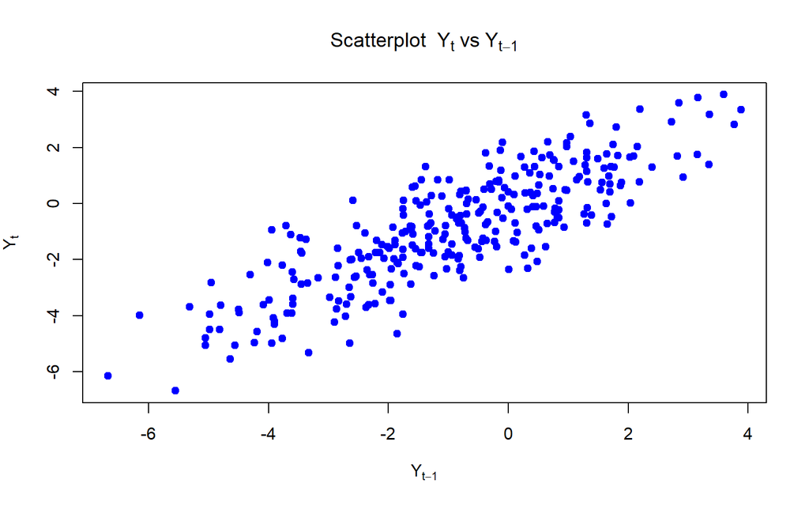

```r
# Yt vs Yt-1
plot(arma22[-1], arma22[-length(arma22)],
     main=expression("Scatterplot " ~ Y[t] ~ "vs" ~ Y[t-1]),
     xlab=expression(Y[t-1]), ylab=expression(Y[t]),
     pch=19, col="blue")
```

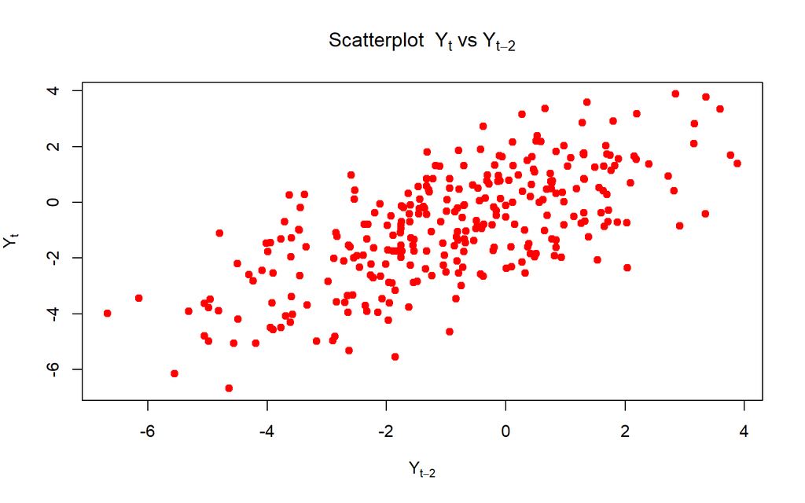

```r
# Yt vs Yt-2
plot(arma22[-c(1,2)], arma22[-((length(arma22)-1):length(arma22))],
     main=expression("Scatterplot " ~ Y[t] ~ "vs" ~ Y[t-2]),
     xlab=expression(Y[t-2]), ylab=expression(Y[t]),
     pch=19, col="red")
```

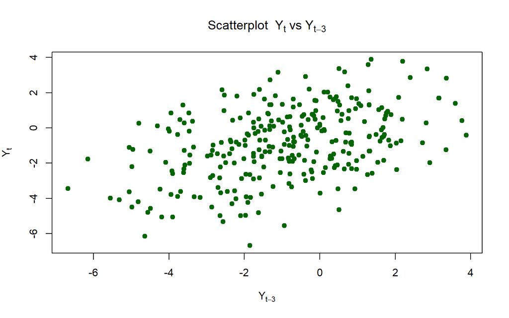

```r
# Yt vs Yt-3
plot(arma22[-c(1,2,3)], arma22[-((length(arma22)-2):length(arma22))],
     main=expression("Scatterplot " ~ Y[t] ~ "vs" ~ Y[t-3]),
     xlab=expression(Y[t-3]), ylab=expression(Y[t]),
     pch=19, col="darkgreen")
```